# Tufts Haplotype Reconstruction

Daniel Gatti

Check the marker name overlap. All of the markers in ‘marker’ are in ‘snps’ from UNC.

```
## [1] TRUE
```

Load in the Geneseek data. There are files that start with ‘FPGM’ that are from UNC and contain data from other investigators. Gillian’s samples have ‘GB’ and/or ‘Tufts’ in their names. The directories that begin with ‘Tufts’ are all Gillian’s samples.

```
## [1] "/media/dmgatti/data0/Tufts/TB/data/genotypes//FPGM12"
```

```
## Reading sample manifest from < /media/dmgatti/data0/Tufts/TB/data/genotypes//FPGM12/Sample_Map.zip > ...
```

```
## Reading genotypes and intensities for 143259 markers x 96 samples from < /media/dmgatti/data0/Tufts/TB/data/genotypes//FPGM12/FPGM-12_FinalReport.zip > ...
```

[output not shown]

```
## Constructing genotype matrix...
```

```
## Constructing intensity matrices...
```

```
##   143259 sites x 96 samples
```

```
## Done.
```

```
## [1] "/media/dmgatti/data0/Tufts/TB/data/genotypes//FPGM14_15"
```

```
## Reading sample manifest from < /media/dmgatti/data0/Tufts/TB/data/genotypes//FPGM14_15/Sample_Map.zip > ...
```

```
## Reading genotypes and intensities for 143259 markers x 96 samples from < /media/dmgatti/data0/Tufts/TB/data/genotypes//FPGM14_15/FPGM_14_15_FinalReport.zip > ...
```

[output not shown]

```
## Constructing genotype matrix...
```

```
## Constructing intensity matrices...
```

```
##   143259 sites x 96 samples
```

```
## Done.
```

```
## Adding 10 individuals to the existing 9.
```

```
## Updating intensity matrices...
```

```
## [1] "/media/dmgatti/data0/Tufts/TB/data/genotypes//Tufts_20160818_Fixed"
```

```
## Reading sample manifest from < /media/dmgatti/data0/Tufts/TB/data/genotypes//Tufts_20160818_Fixed/Sample_Map.zip > ...
```

```
## Reading genotypes and intensities for 143259 markers x 12 samples from < /media/dmgatti/data0/Tufts/TB/data/genotypes//Tufts_20160818_Fixed/Tufts_MURGIGV01_20151105_FinalReport.zip > ...
```

[output not shown]

```
## Constructing genotype matrix...
```

```
## Constructing intensity matrices...
```

```
##   143259 sites x 12 samples
```

```
## Done.
```

```
## Adding 12 individuals to the existing 19.
```

```
## Updating intensity matrices...
```

```
## [1] "/media/dmgatti/data0/Tufts/TB/data/genotypes//Tufts_GIGMUGV01_20160622"
```

```
## Reading sample manifest from < /media/dmgatti/data0/Tufts/TB/data/genotypes//Tufts_GIGMUGV01_20160622/Sample_Map.zip > ...
```

```
## Reading genotypes and intensities for 143259 markers x 48 samples from < /media/dmgatti/data0/Tufts/TB/data/genotypes//Tufts_GIGMUGV01_20160622/Tufts_GIGMUGV01_20160622_FinalReport.zip > ...
```

[output not shown]

```
## Constructing genotype matrix...
```

```
## Constructing intensity matrices...
```

```
##   143259 sites x 48 samples
```

```
## Done.
```

```
## Adding 48 individuals to the existing 31.
```

```
## Updating intensity matrices...
```

```
## [1] "/media/dmgatti/data0/Tufts/TB/data/genotypes//Tufts_MURGIGV01_20151118"
```

```
## Reading sample manifest from < /media/dmgatti/data0/Tufts/TB/data/genotypes//Tufts_MURGIGV01_20151118/Sample_Map.zip > ...
```

```
## Reading genotypes and intensities for 143259 markers x 172 samples from < /media/dmgatti/data0/Tufts/TB/data/genotypes//Tufts_MURGIGV01_20151118/Tufts_MURGIGV01_20151118_FinalReport.zip > ...
```

[output not shown]

```
## Constructing genotype matrix...
```

```
## Constructing intensity matrices...
```

```
##   143259 sites x 172 samples
```

```
## Done.
```

```
## Adding 157 individuals to the existing 79.
```

```
## Updating intensity matrices...
```

```
## [1] "/media/dmgatti/data0/Tufts/TB/data/genotypes//Tufts_MURGIGV01_20161024"
```

```
## Reading sample manifest from < /media/dmgatti/data0/Tufts/TB/data/genotypes//Tufts_MURGIGV01_20161024/Sample_Map.zip > ...
```

```
## Reading genotypes and intensities for 143259 markers x 192 samples from < /media/dmgatti/data0/Tufts/TB/data/genotypes//Tufts_MURGIGV01_20161024/Tufts_MURGIGV01_20161024_FinalReport.zip > ...
```

[output not shown]

```
## Constructing genotype matrix...
```

```
## Constructing intensity matrices...
```

```
##   143259 sites x 192 samples
```

```
## Done.
```

```
## Adding 192 individuals to the existing 236.
```

```
## Updating intensity matrices...
```

```
## [1] "/media/dmgatti/data0/Tufts/TB/data/genotypes//Tufts_MURGIGV01_20161025"
```

```
## Reading sample manifest from < /media/dmgatti/data0/Tufts/TB/data/genotypes//Tufts_MURGIGV01_20161025/Sample_Map.zip > ...
```

```
## Reading genotypes and intensities for 143259 markers x 22 samples from < /media/dmgatti/data0/Tufts/TB/data/genotypes//Tufts_MURGIGV01_20161025/Tufts_MURGIGV01_20161025_FinalReport.zip > ...
```

[output not shown]

```
## Constructing genotype matrix...
```

```
## Constructing intensity matrices...
```

```
##   143259 sites x 22 samples
```

```
## Done.
```

```
## Adding 22 individuals to the existing 428.
```

```
## Updating intensity matrices...
```

```
## [1] "/media/dmgatti/data0/Tufts/TB/data/genotypes//Tufts_MURGIGV01_20161116"
```

```
## Reading sample manifest from < /media/dmgatti/data0/Tufts/TB/data/genotypes//Tufts_MURGIGV01_20161116/Sample_Map.zip > ...
```

```
## Reading genotypes and intensities for 143259 markers x 1 samples from < /media/dmgatti/data0/Tufts/TB/data/genotypes//Tufts_MURGIGV01_20161116/Tufts_MURGIGV01_20161116_FinalReport.zip > ...
```

[output not shown]

```
## Constructing genotype matrix...
```

```
## Constructing intensity matrices...
```

```
##   143259 sites x 1 samples
```

```
## Done.
```

```
## Adding 1 individuals to the existing 450.
```

```
## Updating intensity matrices...
```

```
## [1] "/media/dmgatti/data0/Tufts/TB/data/genotypes//Tufts_School_MURGIGV01_20190909"
```

```
## Reading sample manifest from < /media/dmgatti/data0/Tufts/TB/data/genotypes//Tufts_School_MURGIGV01_20190909/Sample_Map.zip > ...
```

```
## Reading genotypes and intensities for 143259 markers x 120 samples from < /media/dmgatti/data0/Tufts/TB/data/genotypes//Tufts_School_MURGIGV01_20190909/Tufts_School_MURGIGV01_20190909_FinalReport.zip > ...
```

[output not shown]

```
## Constructing genotype matrix...
```

```
## Constructing intensity matrices...
```

```
##   143259 sites x 120 samples
```

```
## Done.
```

```
## Adding 120 individuals to the existing 451.
```

```
## Updating intensity matrices...
```

```
## [1] "/media/dmgatti/data0/Tufts/TB/data/genotypes//Tufts_Univ_Beamer_MURGIGV01_20201105"
```

```
## Reading sample manifest from < /media/dmgatti/data0/Tufts/TB/data/genotypes//Tufts_Univ_Beamer_MURGIGV01_20201105/Sample_Map.zip > ...
```

```
## Reading genotypes and intensities for 143259 markers x 120 samples from < /media/dmgatti/data0/Tufts/TB/data/genotypes//Tufts_Univ_Beamer_MURGIGV01_20201105/Tufts_Univ_Beamer_MURGIGV01_20201105_FinalReport.zip > ...
```

[output not shown]

```
## Constructing genotype matrix...
```

```
## Constructing intensity matrices...
```

```
##   143259 sites x 120 samples
```

```
## Done.
```

```
## Adding 120 individuals to the existing 571.
```

```
## Updating intensity matrices...
```

```
## [1] "/media/dmgatti/data0/Tufts/TB/data/genotypes//Tufts_Univ_Beamer_MURGIGV01_20210426"
```

```
## Reading sample manifest from < /media/dmgatti/data0/Tufts/TB/data/genotypes//Tufts_Univ_Beamer_MURGIGV01_20210426/Sample_Map.zip > ...
```

```
## Reading genotypes and intensities for 143259 markers x 96 samples from < /media/dmgatti/data0/Tufts/TB/data/genotypes//Tufts_Univ_Beamer_MURGIGV01_20210426/Tufts_Univ_Beamer_MURGIGV01_20210426_FinalReport.zip > ...
```

[output not shown]

```
## Constructing genotype matrix...
```

```
## Constructing intensity matrices...
```

```
##   143259 sites x 96 samples
```

```
## Done.
```

```
## Adding 96 individuals to the existing 691.
```

```
## Updating intensity matrices...
```

```
## [1] "/media/dmgatti/data0/Tufts/TB/data/genotypes//Tufts_Univ_Beamer_MURGIGV01_20210513"
```

```
## Reading sample manifest from < /media/dmgatti/data0/Tufts/TB/data/genotypes//Tufts_Univ_Beamer_MURGIGV01_20210513/Sample_Map.zip > ...
```

```
## Reading genotypes and intensities for 143259 markers x 96 samples from < /media/dmgatti/data0/Tufts/TB/data/genotypes//Tufts_Univ_Beamer_MURGIGV01_20210513/Tufts_Univ_Beamer_MURGIGV01_20210513_FinalReport.zip > ...
```

[output not shown]

```
## Constructing genotype matrix...
```

```
## Constructing intensity matrices...
```

```
##   143259 sites x 96 samples
```

```
## Done.
```

```
## Adding 96 individuals to the existing 787.
```

```
## Updating intensity matrices...
```

There are a total of 883 samples read in from the Neogen files. Some are duplicates.

Print out the number of samples in each batch.

```
##                                    Var1 Freq
## 1                                FPGM12    9
## 2                             FPGM14_15   10
## 3                  Tufts_20160818_Fixed   12
## 4              Tufts_GIGMUGV01_20160622   48
## 5              Tufts_MURGIGV01_20151118  157
## 6              Tufts_MURGIGV01_20161024  192
## 7              Tufts_MURGIGV01_20161025   22
## 8              Tufts_MURGIGV01_20161116    1
## 9       Tufts_School_MURGIGV01_20190909  120
## 10 Tufts_Univ_Beamer_MURGIGV01_20201105  120
## 11 Tufts_Univ_Beamer_MURGIGV01_20210426   96
## 12 Tufts_Univ_Beamer_MURGIGV01_20210513   96
```

Check whether we have ~143000 rows.

```
## [1] 143259    883
```

Filter genotypes to remove samples with a on no-call rate > 10%.

These 5 samples were removed. There are now 878 samples.

|  | sample | call_rate |
| --- | --- | --- |
| FPGM12;183 | FPGM12;183 | 0.2658542 |
| FPGM14_15;212 | FPGM14_15;212 | 0.1722754 |
| Tufts_School_MURGIGV01_20190909;503 | Tufts_School_MURGIGV01_20190909;503 | 0.1067158 |
| Tufts_School_MURGIGV01_20190909;583 | Tufts_School_MURGIGV01_20190909;583 | 0.4533258 |
| Tufts_Univ_Beamer_MURGIGV01_20210426;1087 | Tufts_Univ_Beamer_MURGIGV01_20210426;1087 | 0.1090752 |

Make a histogram of the sample genotype call rates.

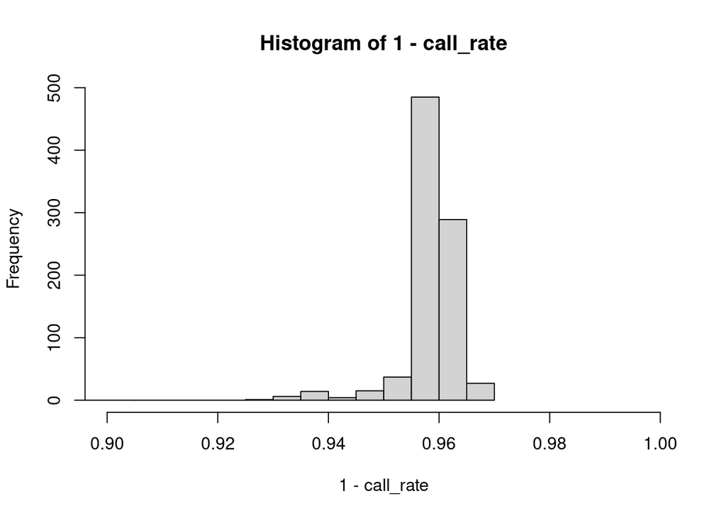

Select UNC tier 1 & 2 markers and ones in Karl’s marker set.

Fix some of the sample IDs that Gillian identified.

Save the genotypes.

```
##             used   (Mb) gc trigger   (Mb)   max used   (Mb)
## Ncells   1728341   92.4    3246602  173.4    2201031  117.6
## Vcells 156106073 1191.0  824424623 6289.9 1030530778 7862.4
```

Look at duplicate samples.

```
## [1] "mouse = 230"
##   FPGM14_15;230 Tufts_GIGMUGV01_20160622;230
## A         18081                        17696
## C         21685                        21478
## G         21931                        21387
## H         40016                        41160
## N           397                          730
## T         17792                        17451
## [1] "mouse = 526"
##   Tufts_School_MURGIGV01_20190909;526.1 Tufts_School_MURGIGV01_20190909;526.2
## A                                 17929                                 17108
## C                                 22074                                 21436
## G                                 22007                                 21812
## H                                 39725                                 41821
## N                                   312                                   342
## T                                 17855                                 17383
```

At the moment, I can’t tell which of the two samples for 230 and 526 are correct. Coat color may help further down the pipeline. I’ll run the haplotype reconstructions for both samples.

Rename the samples in `geno` using unique sample IDs.

Save the sample sex. All mice are female.

Gather the founder and sample genotypes and convert them to qtl2 format.

```
## [1] 8506
```

There are 1251 J:DO samples in the phenotypes and 878 total (non-unique) samples in genotypes.

Of those, 861 samples are found in the intersection between genotypes and phenotypes. At the moment, we can’t do anything with haplotype reconstructions that don’t have a corresponding phenotypes. However, Gillian genotypes BL6 mice and it would be good to see that they are correctly assigned.

```
##           used (Mb) gc trigger   (Mb)   max used   (Mb)
## Ncells 1329796 71.1    3959394  211.5    4949242  264.4
## Vcells 2821684 21.6  659539699 5031.9 1030530778 7862.4
```

# START HERE ONCE ABOVE HAS BEEN RUN.

Read in the DO cross.

```
##  - reading geno
```

```
##  - encoding geno
```

```
##  - reading gmap
```

```
##  - reading pmap
```

```
##  - reading pheno
```

```
##  - reading covar
```

```
##  - reading founder_geno
```

```
##  - encoding founder_geno
```

```
##  - splitting up gmap
```

```
##  - splitting up pmap
```

```
##  - splitting up geno
```

```
##  - splitting up founder_geno
```

```
##  - Using 8 cores
```

```
##              used    (Mb) gc trigger    (Mb)   max used    (Mb)
## Ncells    1471398    78.6    3959394   211.5    4949242   264.4
## Vcells 3886385336 29650.8 5898243677 45000.1 4907031118 37437.7
```

```
##  - Using 4 cores
```

```
##             used   (Mb) gc trigger    (Mb)   max used    (Mb)
## Ncells   1472173   78.7    3959394   211.5    4949242   264.4
## Vcells 909882327 6941.9 4718594942 36000.1 5570969705 42503.2
```